# Time Series Analysis on GE Stock Data to Predict the Close Price of a Stock in FUTURE

### Problem Description

Build time series models in using GE Stock data and the goal is to predict the closing price of a certain stock for future months ahead using time series algorithms and evaluating each of the algorithms.

### Clear the Global Environment

```r
rm(list=ls(all=TRUE))
```

### Library Call

```r
library(forecast)
library(lubridate)
library(DataCombine)
library(imputeTS)
library(dplyr)
library(TTR)
```

```r
library(graphics)
library(data.table)
library(plyr)
library(zoo)
```

### Read Data from csv

- read the csv file

```r
data=read.csv("C:/insofe\\lab_assignments\\Time series\\bse_ge_power_stock.csv")
```

### Observe the data

- What are all the columns given in the data

```r
names(data)
```

```
##  [1] "Date"                       "Open"
##  [3] "High"                       "Low"
##  [5] "Close"                      "WAP"
##  [7] "No..of.Shares"              "No..of.Trades"
##  [9] "Total.Turnover"             "Deliverable.Quantity"
## [11] "X..Deli..Qty.to.Traded.Qty" "Spread.H.L"
## [13] "Spread.C.O"
```

```r
##Summary
summary(data$Close)
```

```
##    Min. 1st Qu.  Median    Mean 3rd Qu.    Max.
##   15.75  133.20  377.60  376.50  577.80 1082.00
```

```r
## Dimensions
dim(data)
```

```
## [1] 4157   13
```

```r
## Unique
summary(data$Date)
```

```
##  1/1/2001  1/1/2002  1/1/2003  1/1/2009  1/1/2013  1/1/2014  1/1/2015
##         1         1         1         1         1         1         1
##  1/1/2016 1/10/2001 1/10/2002 1/10/2003 1/10/2006 1/10/2007 1/10/2008
##         1         1         1         1         1         1         1
## 1/10/2011 1/10/2012 1/10/2013 1/10/2014 1/10/2017 1/11/2001 1/11/2002
##         1         1         1         1         1         1         1
## 1/11/2005 1/11/2007 1/11/2008 1/11/2010 1/11/2011 1/11/2012 1/11/2013
##         1         1         1         1         1         1         1
## 1/11/2016 1/11/2017 1/12/2001 1/12/2004 1/12/2005 1/12/2006 1/12/2007
##         1         1         1         1         1         1         1
## 1/12/2009 1/12/2010 1/12/2011 1/12/2012 1/12/2015 1/12/2016 1/12/2017
##         1         1         1         1         1         1         1
## 1/13/2003 1/13/2004 1/13/2005 1/13/2006 1/13/2009 1/13/2010 1/13/2011
##         1         1         1         1         1         1         1
## 1/13/2012 1/13/2014 1/13/2015 1/13/2016 1/13/2017 1/14/2002 1/14/2003
##         1         1         1         1         1         1         1
## 1/14/2004 1/14/2005 1/14/2008 1/14/2009 1/14/2010 1/14/2011 1/14/2013
##         1         1         1         1         1         1         1
## 1/14/2014 1/14/2015 1/14/2016 1/15/2001 1/15/2002 1/15/2003 1/15/2004
##         1         1         1         1         1         1         1
## 1/15/2007 1/15/2008 1/15/2009 1/15/2010 1/15/2013 1/15/2014 1/15/2015
##         1         1         1         1         1         1         1
## 1/15/2016 1/16/2001 1/16/2002 1/16/2003 1/16/2004 1/16/2006 1/16/2007
##         1         1         1         1         1         1         1
## 1/16/2008 1/16/2009 1/16/2013 1/16/2014 1/16/2015 1/16/2017 1/17/2001
##         1         1         1         1         1         1         1
## 1/17/2002 1/17/2003 1/17/2005 1/17/2006 1/17/2007 1/17/2008 1/17/2011
##         1         1         1         1         1         1         1
## 1/17/2012   (Other)
##         1      4058
```

## Basic data View

```r
head(data,30)
```

```
##         Date   Open   High    Low  Close    WAP No..of.Shares
## 1   8/4/2017 699.00 710.00 691.00 709.20 705.21          2537
## 2   8/3/2017 705.15 708.00 697.95 705.05 704.12          1804
## 3   8/2/2017 700.05 713.60 699.00 710.65 708.53          4491
## 4   8/1/2017 717.00 717.00 678.85 706.00 699.20          8257
## 5  7/31/2017 714.00 717.00 707.40 714.35 712.20          3870
## 6  7/28/2017 680.00 712.50 680.00 710.30 706.64         13180
## 7  7/27/2017 695.00 721.00 667.00 678.65 692.89          6484
## 8  7/26/2017 660.00 746.50 660.00 691.35 709.36         30980
## 9  7/25/2017 651.35 663.00 650.00 660.70 654.42          2397
## 10 7/24/2017 640.10 660.00 640.10 651.50 649.78           430
## 11 7/21/2017 645.05 655.00 644.95 648.95 649.04           757
## 12 7/20/2017 650.00 655.00 640.10 649.00 652.00          1490
## 13 7/19/2017 673.95 673.95 632.90 649.95 650.05          1249
## 14 7/18/2017 625.50 647.70 625.00 637.00 634.63          1354
```

[output cut: 78 more lines]

## Summary of the entire data set

```r
summary(data)
```

```
##        Date           Open             High             Low
##  1/1/2001:   1   Min.   :  16.0   Min.   :  16.4   Min.   :  15.05
##  1/1/2002:   1   1st Qu.: 134.0   1st Qu.: 137.0   1st Qu.: 131.30
##  1/1/2003:   1   Median : 378.0   Median : 385.0   Median : 371.00
##  1/1/2009:   1   Mean   : 377.6   Mean   : 385.0   Mean   : 369.73
##  1/1/2013:   1   3rd Qu.: 580.0   3rd Qu.: 590.0   3rd Qu.: 570.00
##  1/1/2014:   1   Max.   :1099.0   Max.   :1109.0   Max.   :1060.00
##  (Other) :4151
##      Close              WAP          No..of.Shares     No..of.Trades
##  Min.   :  15.75   Min.   :  15.93   Min.   :      1   Min.   :    1
##  1st Qu.: 133.15   1st Qu.: 134.00   1st Qu.:   5179   1st Qu.:  193
##  Median : 377.55   Median : 378.62   Median :  18000   Median :  604
##  Mean   : 376.48   Mean   : 377.65   Mean   :  58149   Mean   : 1296
##  3rd Qu.: 577.80   3rd Qu.: 580.05   3rd Qu.:  53667   3rd Qu.: 1468
##  Max.   :1082.10   Max.   :1091.21   Max.   :3067625   Max.   :77660
##
##  Total.Turnover      Deliverable.Quantity X..Deli..Qty.to.Traded.Qty
##  Min.   :3.300e+01   Min.   :    39       Min.   :  1.57
##  1st Qu.:1.172e+06   1st Qu.:  3047       1st Qu.: 31.63
##  Median :5.167e+06   Median :  9113       Median : 45.26
##  Mean   :2.222e+07   Mean   : 21018       Mean   : 47.42
##  3rd Qu.:1.783e+07   3rd Qu.: 23441       3rd Qu.: 61.57
##  Max.   :1.993e+09   Max.   :441337       Max.   :100.00
##                      NA's   :444          NA's   :444
##    Spread.H.L       Spread.C.O
##  Min.   :  0.00   Min.   :-88.650
##  1st Qu.:  5.40   1st Qu.: -5.200
##  Median : 12.00   Median : -0.700
##  Mean   : 15.28   Mean   : -1.084
##  3rd Qu.: 20.20   3rd Qu.:  2.500
##  Max.   :250.00   Max.   : 90.950
##
```

```r
str(data)
```

```
## 'data.frame':    4157 obs. of  13 variables:
##  $ Date                      : Factor w/ 4157 levels "1/1/2001","1/1/2002",..: 3766 3733 3605 3488 3401 3352 3340 3327 3316 3302 ...
##  $ Open                      : num  699 705 700 717 714 ...
##  $ High                      : num  710 708 714 717 717 ...
##  $ Low                       : num  691 698 699 679 707 ...
##  $ Close                     : num  709 705 711 706 714 ...
##  $ WAP                       : num  705 704 709 699 712 ...
##  $ No..of.Shares             : int  2537 1804 4491 8257 3870 13180 6484 30980 2397 430 ...
##  $ No..of.Trades             : int  97 77 220 750 220 637 487 2052 102 43 ...
##  $ Total.Turnover            : int  1789108 1270228 3181986 5773259 2756203 9313504 4492699 21975976 1568645 279406 ...
##  $ Deliverable.Quantity      : int  2213 1338 3136 4596 2308 7115 2307 9473 1708 258 ...
##  $ X..Deli..Qty.to.Traded.Qty: num  87.2 74.2 69.8 55.7 59.6 ...
##  $ Spread.H.L                : num  19 10.1 14.6 38.1 9.6 ...
##  $ Spread.C.O                : num  10.2 -0.1 10.6 -11 0.35 ...
```

### Observation & Analysis

- We need to have one data point per month price so therefore we need to aggregate them by day of * month
- R has read the data column as factor we need convert it to date format

```r
data2=data.frame(data[,c("Date","Close")])
head(data2)
```

```
##        Date  Close
## 1  8/4/2017 709.20
## 2  8/3/2017 705.05
## 3  8/2/2017 710.65
## 4  8/1/2017 706.00
## 5 7/31/2017 714.35
## 6 7/28/2017 710.30
```

```r
data2$Date=as.Date(data2$Date,format="%m/%d/%Y")
```

### Missing values in time series

- Some times there will be missing entries in dates which will create a missing day in the data or if it is quarter,month or annual .
- Observe the data to find if any

```r
head(data2)
```

```
##         Date  Close
## 1 2017-08-04 709.20
## 2 2017-08-03 705.05
## 3 2017-08-02 710.65
## 4 2017-08-01 706.00
## 5 2017-07-31 714.35
## 6 2017-07-28 710.30
```

```r
str(data2)
```

```
## 'data.frame':    4157 obs. of  2 variables:
##  $ Date : Date, format: "2017-08-04" "2017-08-03" ...
##  $ Close: num  709 705 711 706 714 ...
```

### Detection of the missing values

- Create a date field which consists of continuous sequence of dates
- Check against this with the current price data and find out the missing dates.
- Join this variable to the current data to see the missing dates

```r
minDate=min(as.Date(data2$Date,format="%m/%d/%Y"))
maxDate =max(as.Date(data2$Date,format="%m/%d/%Y"))
```

### Creating a data frame for sequence of Days

```r
seq <- data.frame("dateRange"=seq(minDate,maxDate,by="days"))
```

#### Merge the data frames of seq of dates with the dates of sale

```r
data3=merge(seq,data2,by.x="dateRange",by.y="Date",all.x=T)
head(data3)
```

```
##    dateRange  Close
## 1 2000-03-21 119.00
## 2 2000-03-22 109.50
## 3 2000-03-23 100.75
## 4 2000-03-24  92.90
## 5 2000-03-25     NA
## 6 2000-03-26     NA
```

### Impuation of Missing Values

```r
data3$Close<-na.locf(data3$Close)
head(data3)
```

```
##    dateRange  Close
## 1 2000-03-21 119.00
## 2 2000-03-22 109.50
## 3 2000-03-23 100.75
## 4 2000-03-24  92.90
## 5 2000-03-25  92.90
## 6 2000-03-26  92.90
```

### Observation on MEAN_PRICE

```r
data3$Month <-as.numeric(format(data3$dateRange,format="%Y.%m"))
data4<-ddply(data3, .(Month),summarize,MEAN_Close=mean(Close))
head(data4)
```

```
##     Month MEAN_Close
## 1 2000.03   89.22727
## 2 2000.04   62.27333
## 3 2000.05   36.85484
## 4 2000.06   32.02833
## 5 2000.07   31.79677
## 6 2000.08   23.58871
```

### Splitting of the Data

- Random split is not possible because here we will be in need of sequence where by we miss the data points
- splitting is done by sequential splitting

```r
Train=data4[which(data4$Month<=2017.04),]
Test=data4[which(data4$Month>2017.04),]
```

### converting into time series

- our target variable is close price and each month has a close price aggregated

```r
Price <- ts(Train$MEAN_Close,frequency =12)
```

### Vizualize the time series Data

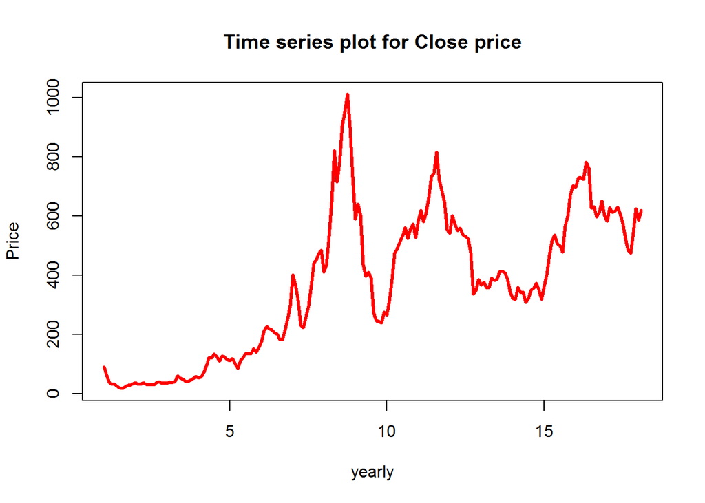

```r
plot(Price,
     type="l",
     lwd=3,
     col="red",
     xlab="yearly",
     ylab="Price",
     main="Time series plot for Close price")
```

### Decomposed Time Series * Decompose will provide us with the info on seasonality,trend and randomness

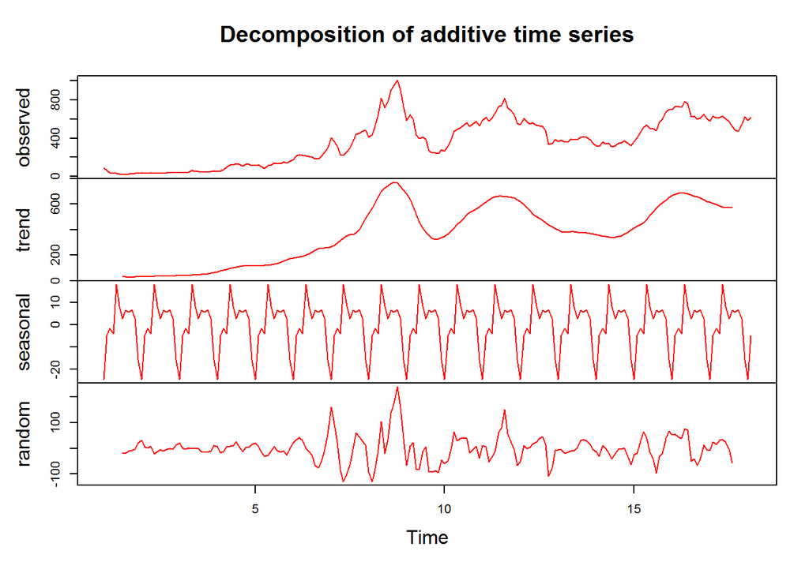

```r
Pricedecomposed=decompose(Price)
plot(Pricedecomposed,col="Red")
```

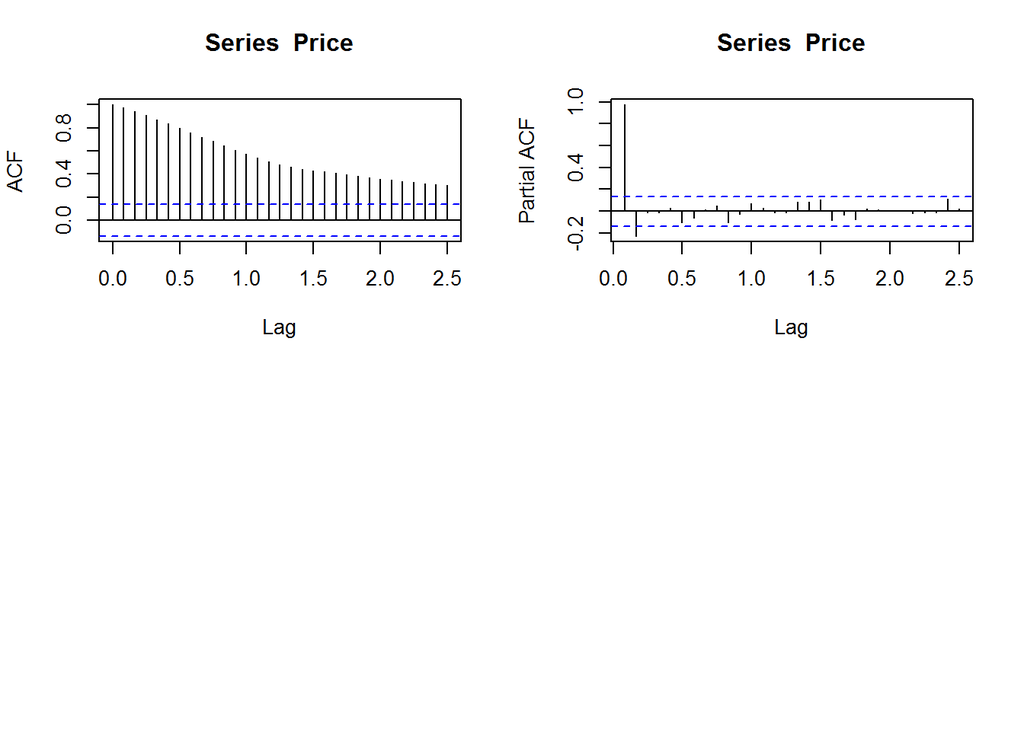

```r
par(mfrow=c(2,2))
acf(Price,lag=30)
pacf(Price,lag=30)
```

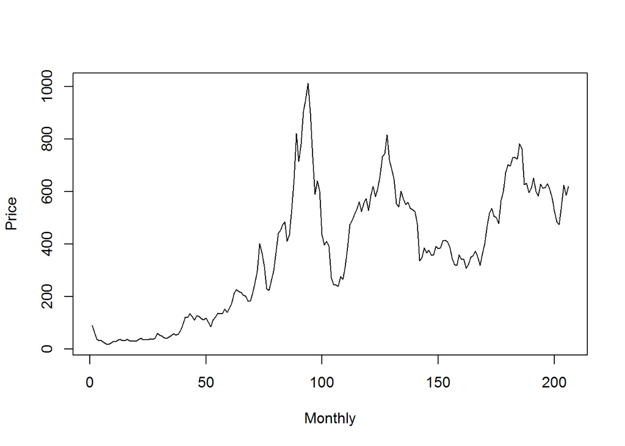

```r
Price1 <- ts(Train$MEAN_Close, frequency =1)
plot(Price1,xlab = "Monthly",ylab="Price")
```

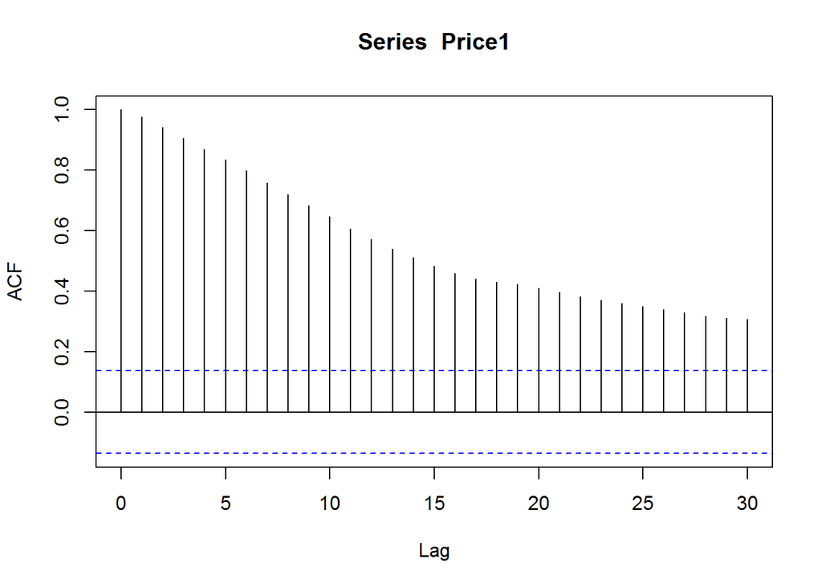

```r
acf(Price1,lag=30)
```

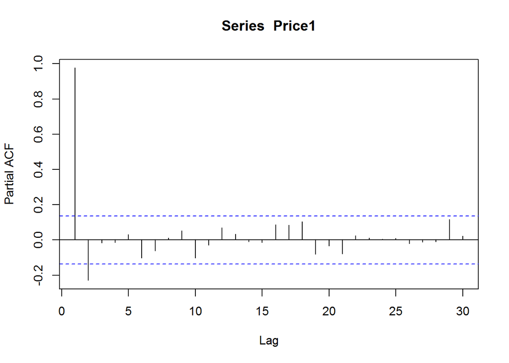

```r
pacf(Price1,lag=30)
```

Looking at the Y scale in ACF we observe that trend is more dominant than seasonality * Data is not stationay and we need to stationarize the data

### Stationarize by differencing

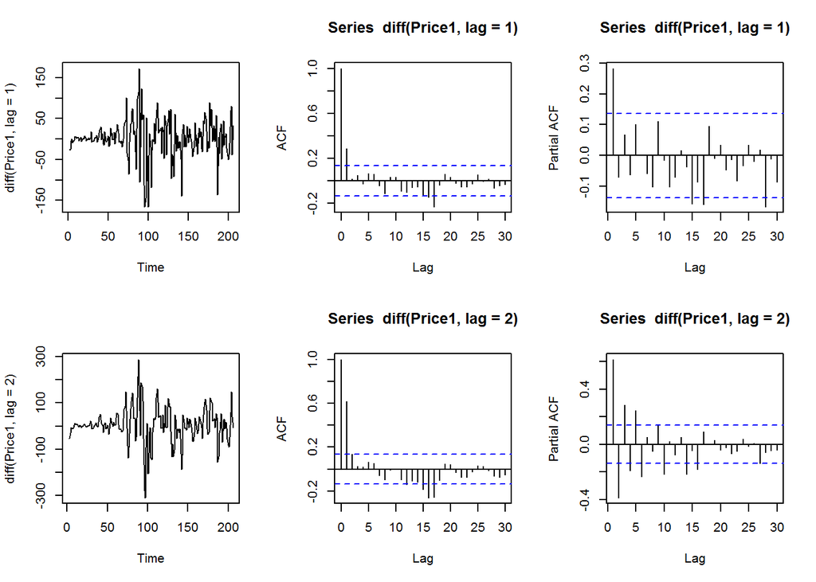

```r
par(mfrow=c(2,3))
plot(diff(Price1,lag = 1),type="l"); acf(diff(Price1,lag = 1),lag=30) ;pacf(diff(Price1,lag = 1),lag=30)
plot(diff(Price1,lag=2),type="l");  acf(diff(Price1,lag = 2),lag=30); pacf(diff(Price1,lag = 2),lag=30)
```

* one lag has stationarize the data we can use ndiffs of forecast package to check no of differences required to stationarize the data

```r
ndiffs(Price)
```

```
## [1] 1
```

### Weighted Moving Averages

```r
fitwma<- WMA(Price,n=2,1:2)
wmaMape <- mean(abs((Price[2:length(Price)]-fitwma[2:length(Price)])/Price[2:length(Price)]))
wmaMape
```

```
## [1] 0.0326578
```

```r
pred<-forecast(fitwma,h=4)
```

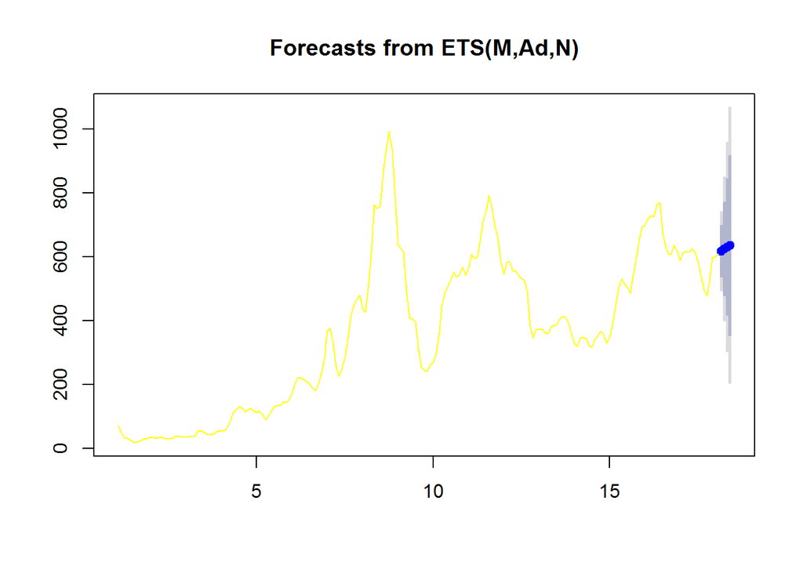

```r
plot(pred)
lines(fitwma,col="yellow")
```

### Exponential Moving Averages

```r
fitEma <- EMA(Price, n = 2)
emaMape <- mean(abs((Price[2:length(Price)]-fitEma[2:length(Price)])/Price[2:length(Price)]))
emaMape
```

```
## [1] 0.03893118
```

```r
pred<-forecast(fitEma,h=4)
```

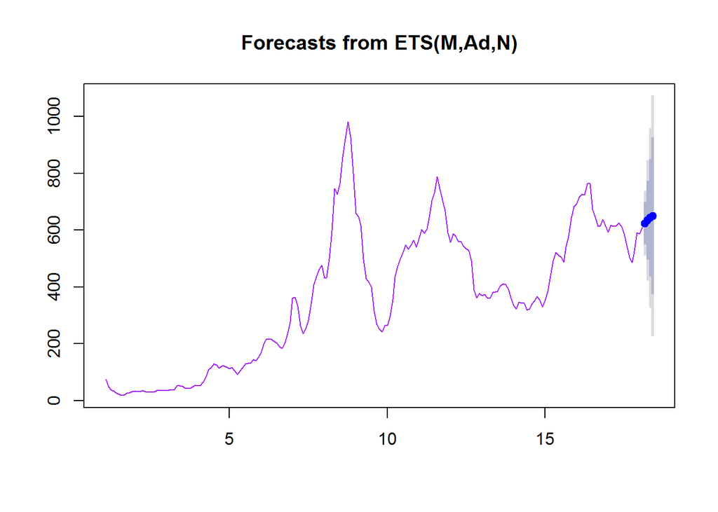

```r
plot(pred)
lines(fitEma,col="purple")
```

## Build a HoltWinters model with trend

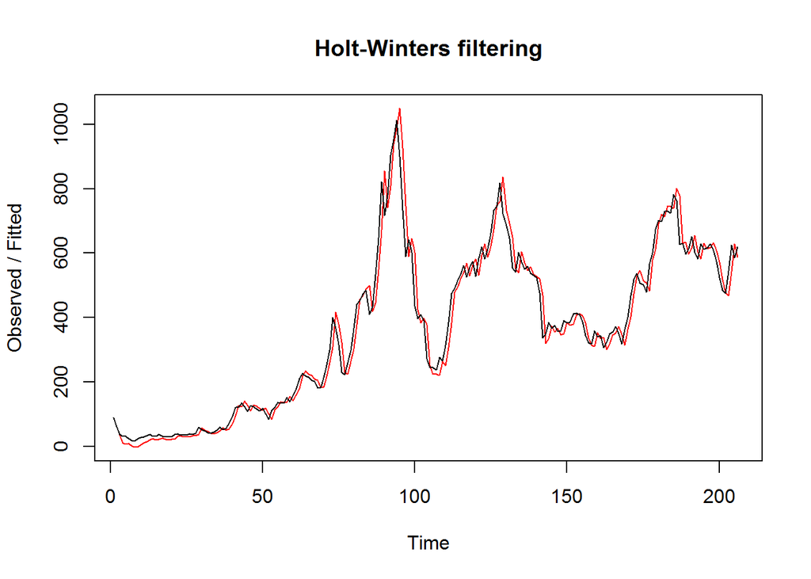

```r
holtpriceforecast <- HoltWinters(Train$MEAN_Close,gamma=FALSE)
plot(holtpriceforecast)
```

```r
head(holtpriceforecast$fitted)
```

```
## Time Series:
## Start = 3
## End = 8
## Frequency = 1
##        xhat    level     trend
## 3 35.319394 62.27333 -26.95394
## 4 10.013087 36.85484 -26.84175
## 5  6.795135 32.02833 -25.23320
## 6  8.390331 31.79677 -23.40644
## 7  1.292742 23.58871 -22.29597
## 8 -1.889508 19.10500 -20.99451
```

## HoltWinters model with trend and Seasonality

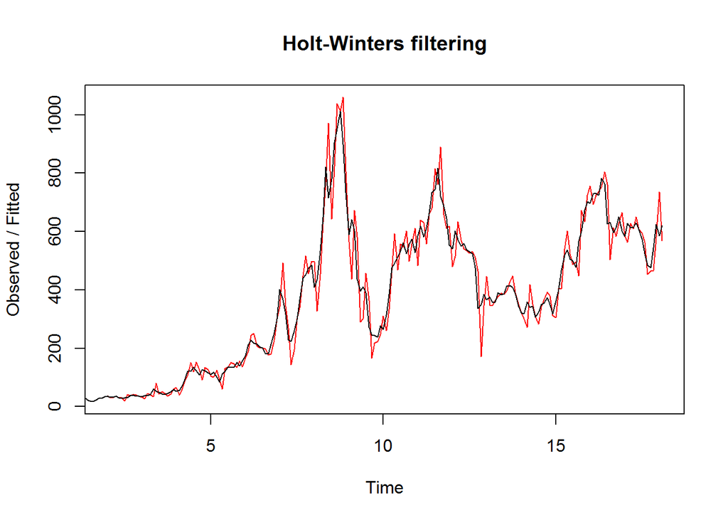

```r
priceholtforecast <-
HoltWinters(Price, beta=TRUE, gamma=TRUE, seasonal="additive")
plot(priceholtforecast)
```

```r
head(priceholtforecast$fitted)
```

```
##           xhat    level      trend     season
## Jan 2 37.59994 28.58498  0.3056140  8.7093501
## Feb 2 30.02902 27.60677 -0.9782080  3.4004545
## Mar 2 31.67783 28.44161  0.8348372  2.4013819
## Apr 2 36.47794 29.63567  1.1940559  5.6482233
## May 2 30.97621 30.73996  1.1042931 -0.8680401
## Jun 2 29.66028 31.52711  0.7871481 -2.6539752
```

*Since we are building the models on monthly data, we will get 12 seasonal components.

### Prediction on the Train

```r
holtforecastTrain <- data.frame(priceholtforecast$fitted)
holtforecastTrainpredictions <- holtforecastTrain$xhat
head(holtforecastTrainpredictions)
```

```
## [1] 37.59994 30.02902 31.67783 36.47794 30.97621 29.66028
```

### Prediction on test data

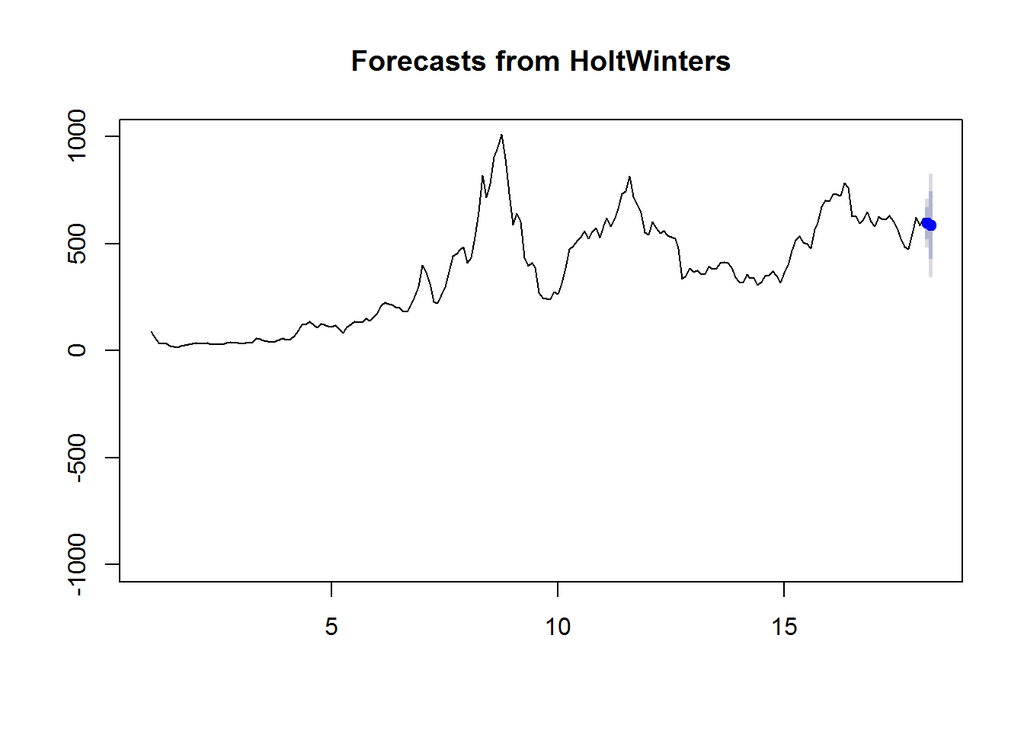

```r
priceforecast<-forecast(priceholtforecast,h = 2)
plot(priceforecast,ylim = c(-1000,1000))
```

## Considering the difference from the graph as d=1 to stationarize

```r
model1 <- arima(Price,c(0,1,0))
model1
```

```
##
## Call:
## arima(x = Price, order = c(0, 1, 0))
##
##
## sigma^2 estimated as 2139:  log likelihood = -1076.84,  aic = 2155.69
```

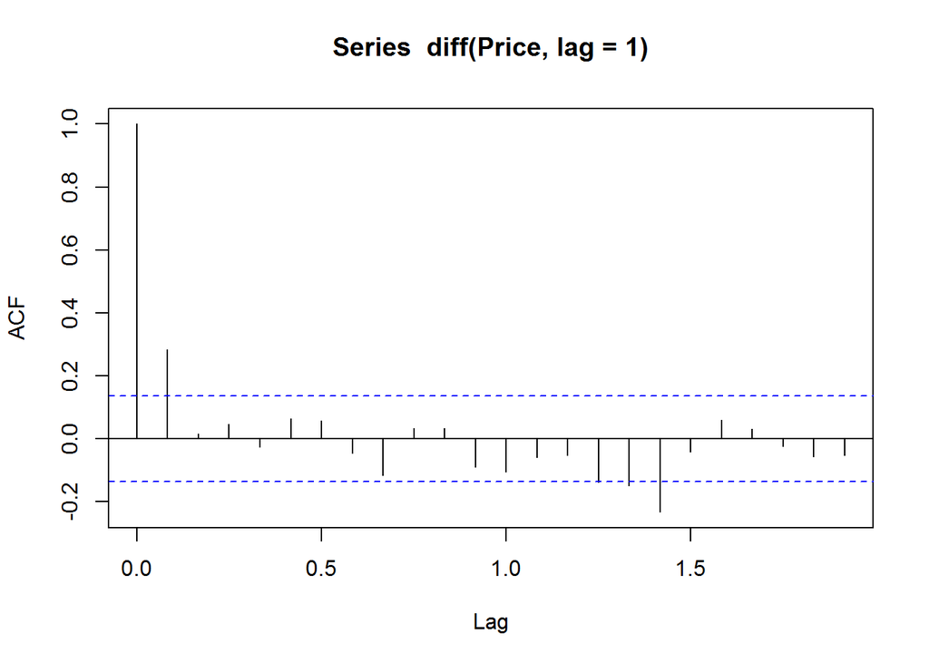

```r
acf(diff(Price,lag = 1))
```

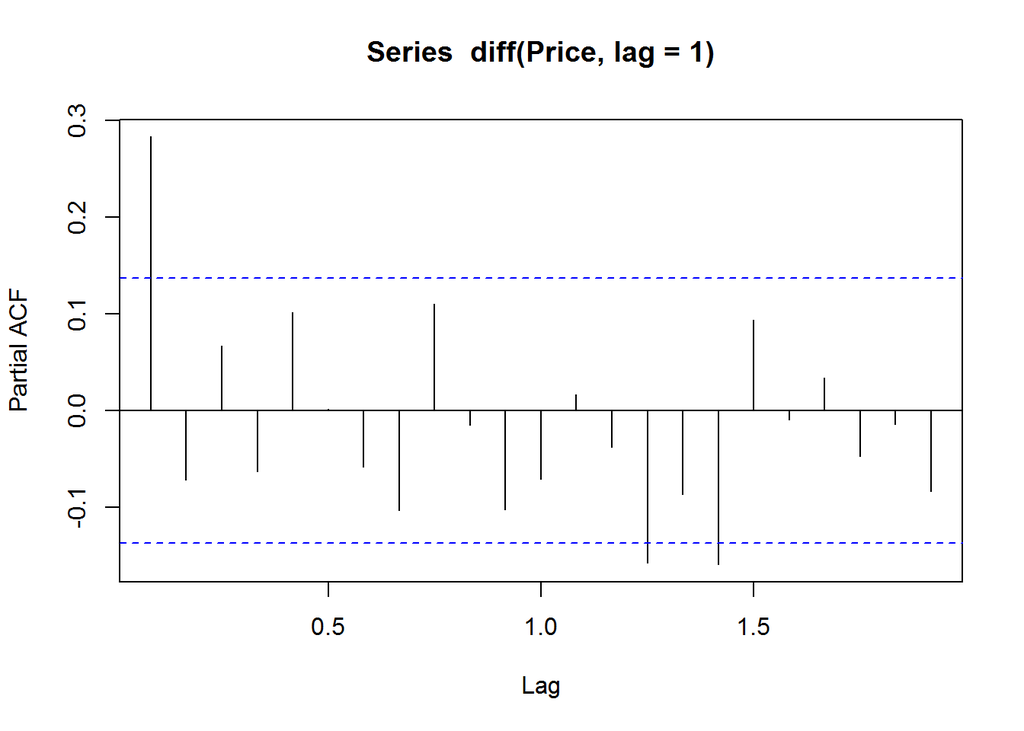

```r
pacf(diff(Price,lag = 1))
```

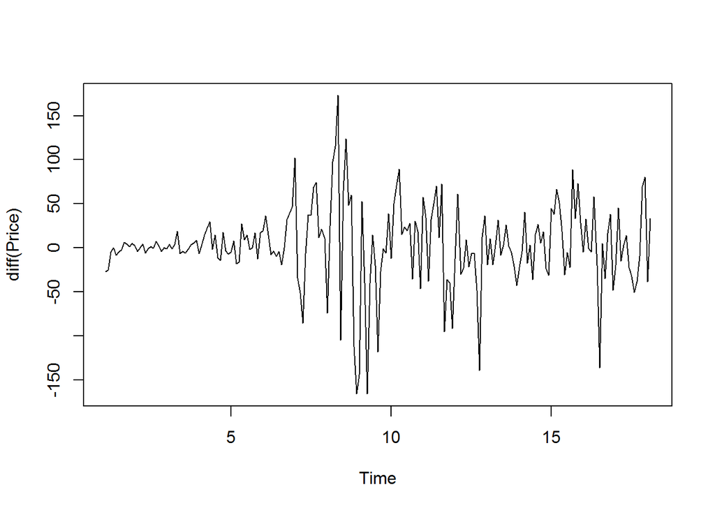

```r
plot(diff(Price))
```

```r
model2 <- arima(Price,c(0,2,0))
model2
```

```
##
## Call:
## arima(x = Price, order = c(0, 2, 0))
##
##
## sigma^2 estimated as 3062:  log likelihood = -1108.19,  aic = 2218.39
```

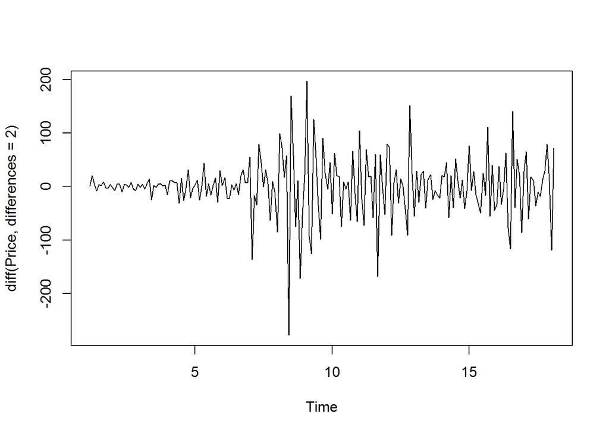

```r
plot(diff(Price,differences = 2))
```

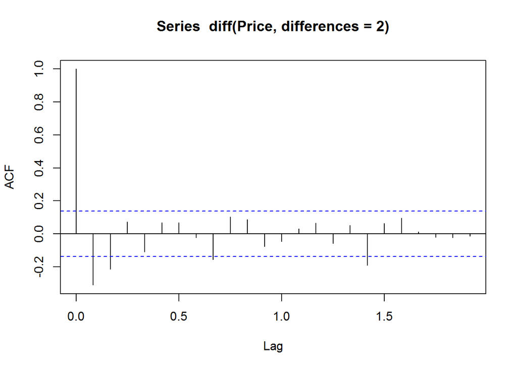

```r
acf(diff(Price,differences = 2))
```

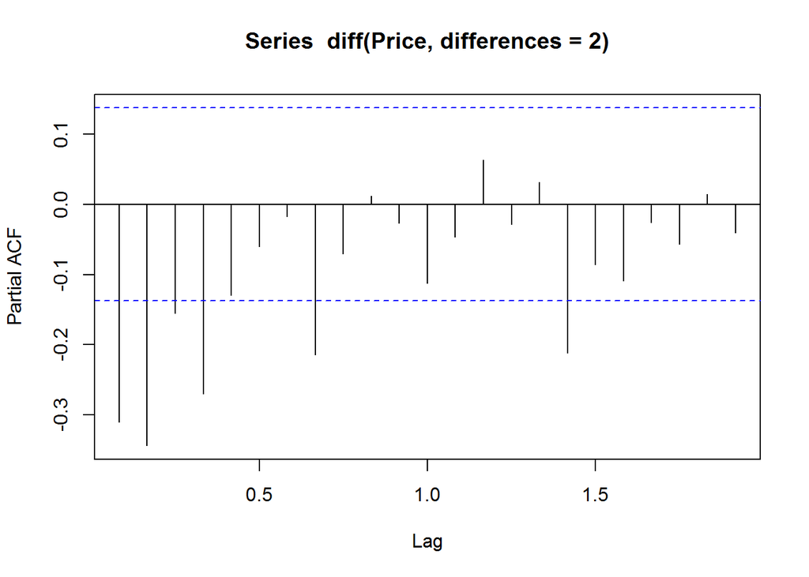

```r
pacf(diff(Price,differences = 2))
```

* Observing the acf and pacf there is significant lag in acf and also in pacf that has to be taken care

```r
model3 <- arima(Price,c(1,1,1))
model3
```

```
##
## Call:
## arima(x = Price, order = c(1, 1, 1))
##
## Coefficients:
##           ar1     ma1
##       -0.2511  0.5620
## s.e.   0.2900  0.2595
##
## sigma^2 estimated as 1939:  log likelihood = -1066.87,  aic = 2139.74
```

## Plots of the models

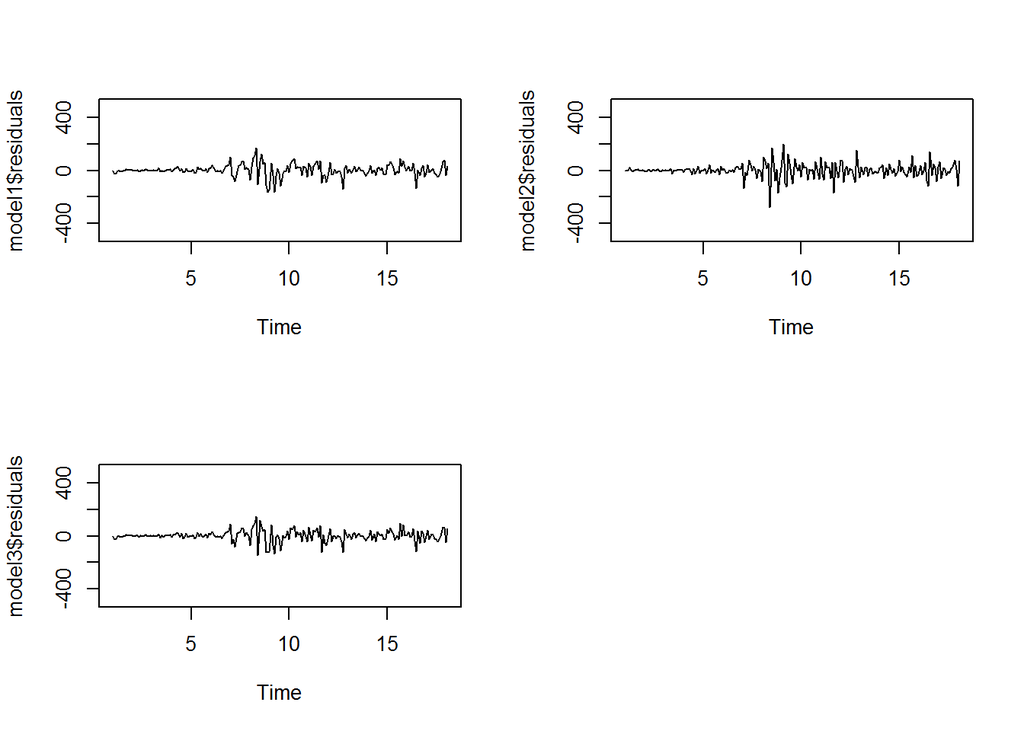

```r
par(mfrow=c(2,2))
plot(model1$residuals,ylim=c(-500,500))
plot(model2$residuals,ylim=c(-500,500))
plot(model3$residuals,ylim=c(-500,500))
```

### Auto Arima

```r
MODEL_ARIMA <- auto.arima(Price, ic='aic')
summary(MODEL_ARIMA)
```

```
## Series: Price
## ARIMA(0,1,1)
##
## Coefficients:
##          ma1
##       0.3258
## s.e.  0.0713
##
## sigma^2 estimated as 1954:  log likelihood=-1067.17
## AIC=2138.33   AICc=2138.39   BIC=2144.98
##
## Training set error measures:
##                    ME     RMSE      MAE       MPE     MAPE      MASE
## Training set 2.009008 43.99356 29.76711 0.2308382 9.236536 0.2035261
##                    ACF1
## Training set -0.0109429
```

### Forecast on the models

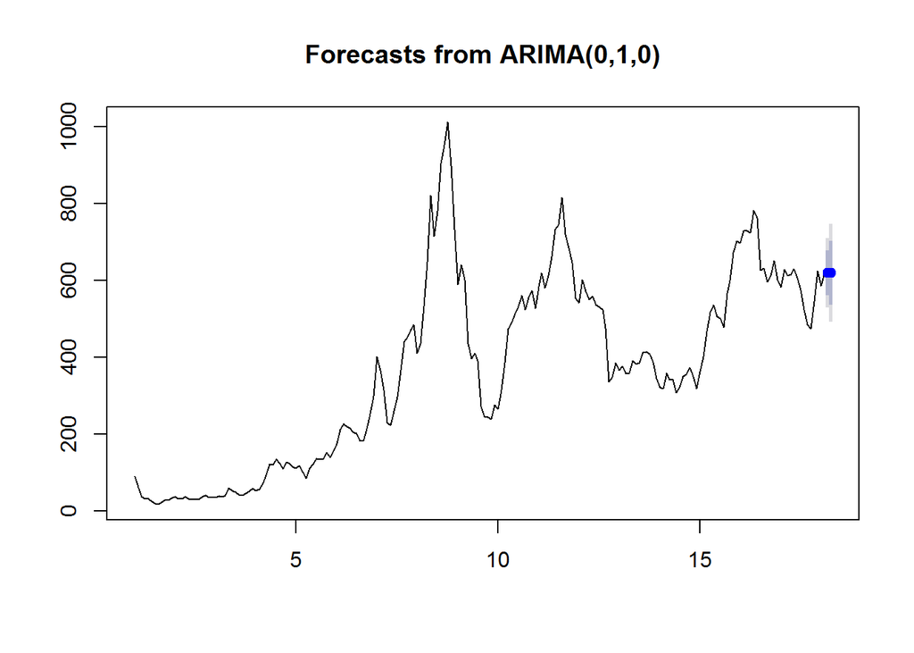

```r
pricearimaforecasts1 <- forecast(model1, h=2)
plot(pricearimaforecasts1)
```

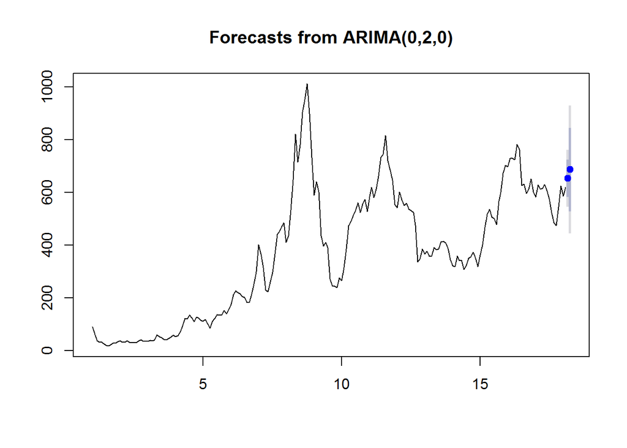

```r
pricearimaforecasts2 <- forecast(model2, h=2)
plot(pricearimaforecasts2)
```

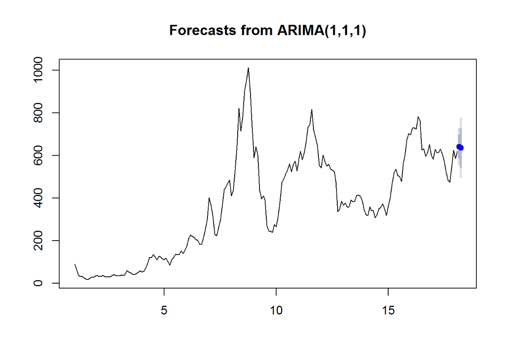

```r
pricearimaforecast3 <- forecast(model3, h=2)
plot(pricearimaforecast3)
```

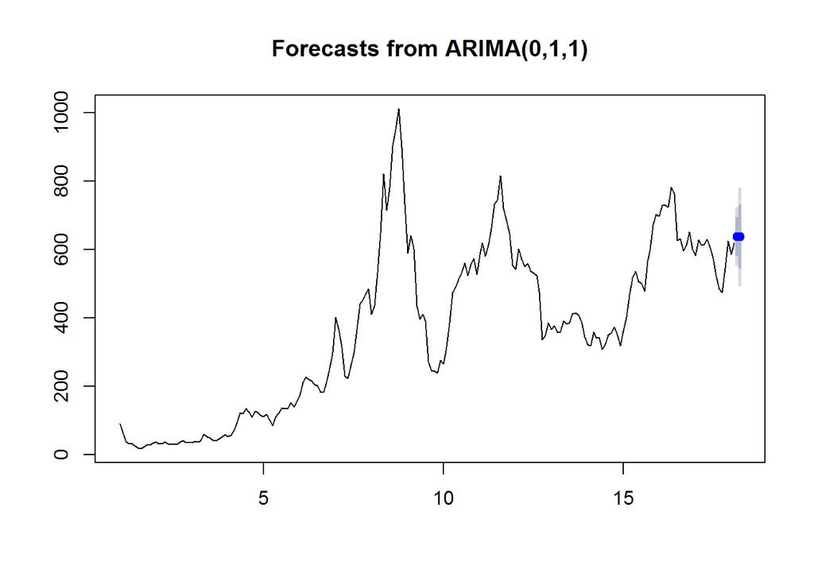

```r
pricearimaforecasts_autArima<- forecast(MODEL_ARIMA,h=2)
plot(pricearimaforecasts_autArima,flwd = 2)
```

```r
summary(MODEL_ARIMA)
```

```
## Series: Price
## ARIMA(0,1,1)
##
## Coefficients:
##          ma1
##       0.3258
## s.e.  0.0713
##
## sigma^2 estimated as 1954:  log likelihood=-1067.17
## AIC=2138.33   AICc=2138.39   BIC=2144.98
##
## Training set error measures:
##                    ME     RMSE      MAE       MPE     MAPE      MASE
## Training set 2.009008 43.99356 29.76711 0.2308382 9.236536 0.2035261
##                    ACF1
## Training set -0.0109429
```

- Model 1 was constructed with no trend and no seasonality and therefore the prediction will be same as present.